```python
import numpy as np
import Pickles

import matplotlib.pyplot as plt
import matplotlib.cm as cm
%matplotlib inline

from IPython.display import display
import ipywidgets as widgets
```

# CIFAR 10

A quick exploration of the CIFAR10 data set and a play with some kernel functions.

32 x 32 = 1024 pixels. with 3 values in each, red, green, blue. = 3 * 1024 = 3072

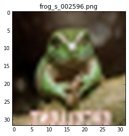

```python
batch1 = Pickles.unpickle('cifar-10-batches-py/data_batch_1')

def plotCIFAR(im, Title = 'CIFAR',colourmap=None):
    plt.figure()
    plt.imshow(np.rot90(im,k=3),interpolation='spline36', aspect = 1,cmap = colourmap)
    plt.title(Title)

def showCIFARimg(n):
    im = batch1['data'][n].reshape( (32,32,3), order='F')
    plotCIFAR(im,Title = batch1['filenames'][n])

widgets.interactive(showCIFARimg,n=(0,10000-1))
```

## Kernels

Why a window of 3? What size is best, what ratio of window to stride is ideal?

Do the filters always have to be square? What about different filter shapes for different data structures/encodings? How could this help us recognise certain patterns? Or, does if not matter as the CNN a universal recogniser (could we prove that any/all features can be represented)? Although, it could make it faster/require less parameters if the kernels were better suited to the task?

How much sense does it really make to build curves out of straight lines? Could we represent the image using polar coordinates, or in a hyperbolic geometry? What if we mapped the geometry onto some other type (of geometry)? Instead of convolving left-right, up-down, ... we could convolve along geodesics, or hyperbolas, would this be better at picking out ???.

```python
def steps(n,stride,window):
    return int((n - window )/stride + 1)

def steps_inverse(m,stride,window):
    return ((m-1)*stride + window)
```

```python
if __name__ == '__main__':
    print('## Testing steps')
    print('stride = 2')
    n = 32
    for i in range(4):
        n = steps(n,2,3)
        print(n)
```

```
## Testing steps
stride = 2
15
7
3
1
```

### Zero padding

Does this bias some inputs? Are there negative effects from doing too much padding?

```python
def zeroPad(image, p = None,even = True):
    if even:
        return np.lib.pad(image,((0,0),(0,0),(p,p),(p,p)),'constant', constant_values=0)
    else:
        return np.lib.pad(image,((0,0),(0,0),(p,0),(p,0)),'constant', constant_values=0)
```

```python
if __name__ == '__main__':
    im = np.random.random((100,3,14,14))
    im = zeroPad(im,p=1,even = False)
    print(im.shape)
```

```
(100, 3, 15, 15)
```

```python
if __name__ == '__main__':
    im = np.random.random((100,3,7,7))
    n = im.shape[-1]
    stride = 2
    window = 3

    m=steps(n,stride,window)
    print('The number of convolve steps across the image =', m)
    diff = n-steps_inverse(m,stride,window)
    print('The difference between the steps and the real shape =',diff)

    if diff >0:
        im = zeroPad(im,p=diff)#diff/2??
        print(im.shape)
        n = im.shape[-1]
        m=steps(n,stride,window)
        print('The number of convolve steps across the image =', m)
        diff = n-steps_inverse(m,stride,window)
        print('The difference between the steps and the real shape =',diff)
```

```
The number of convolve steps across the image = 3
The difference between the steps and the real shape = 0
```

## Kernels

```python
class Kernels(): #has a shape, weights, biases and a stride
    def __init__(self,shape,stride = 2):
        self.shape = shape
        self.weights = np.random.standard_normal(shape)
        self.biases = np.random.standard_normal(self.shape[0]) #???

        self.stride = stride
        self.k2,self.k1,_,self.w = self.shape

    def fdot(self,x):
        return  np.tensordot(x,self.weights,[[1,2,3],[1,2,3]]) + self.biases

    def convolve(self,x):
        N,_,_,n = x.shape
        self.m = steps(n,self.stride,self.w)
        Results = np.zeros((N,self.k2,self.m,self.m))
        self.Inputs = np.zeros((N,self.m,self.m,self.k1,self.w,self.w))
        for i in range(self.m):
            I = i*self.stride
            for j in range(self.m):
                J = j*self.stride
                self.Inputs[:,i,j,:,:,:] = x[:,:,I:I+self.w,J:J+self.w] #doesnt seem very space efficient?
                Results[:,:,i,j] = self.fdot(x[:,:,I:I+self.w,J:J+self.w])
        self.Inputs = np.sum(self.Inputs, axis = (0,1,2))
        return Results

    def deconvolve(self,x): #given a delta for each kernel
        k2,k1,_,w = self.weights.shape
        n = steps_inverse(self.m,self.stride,w)
        Results = np.zeros((k1,n,n))

        for i in range(self.m):
            I = i*self.stride
            for j in range(self.m):
                J = j*self.stride
                #tile the delta onto the previous image space
                #through each kernels weights
                Results[:,I:I+w,J:J+w] += np.tensordot(self.weights,x,[[0],[0]]).squeeze() #biases??
        return Results
```

```python
### Use a single kernel for the entire input
if __name__ == '__main__':
    Image = np.random.standard_normal((100,3,3,3)) #and an input image of 3x 5x5
    Ker1 = Kernels((10,3,3,3)) #for 10 different kernels of size 3x5x5
    output1 = Ker1.fdot(Image)
    print('Number of parameters =',Ker1.weights.size)
    print('Forward tensor dot: ',Image.shape,'->',output1.shape)

    Image = np.random.standard_normal((100,20,15,15))
    Ker2 = Kernels((40,20,3,3))
    output2 = Ker2.convolve(Image)
    print('Convolve: ',Image.shape,'->',output2.shape)

    delta = np.random.standard_normal((40,1))
    output3 = Ker2.deconvolve(delta)
    print('De-convolve: ',delta.shape,'->',output3.shape)
```

```
Number of parameters = 270
Forward tensor dot:  (100, 3, 3, 3) -> (100, 10)
Convolve:  (100, 20, 15, 15) -> (100, 40, 7, 7)
De-convolve:  (40, 1) -> (20, 15, 15)
```

## Basic image processing

Lets test out our kernel on an image.

```
s
```

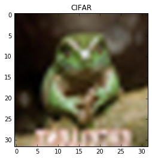

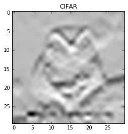

```python
def edgedetector(n):
    im = batch1['data'][n].reshape( (1,32,32,3), order='F')

    # an edge detector
    shape = (1,3,3,3)
    K = Kernels(shape,stride = 1)
    K.weights = np.zeros(shape)
    K.weights[:,:,1,0] = 1
    K.weights[:,:,1,1] = -1
    #convolve the edge detector with the image
    image1 = K.convolve(np.transpose(im,(0,3,1,2)))

    plotCIFAR(im.reshape(32,32,3))
    plotCIFAR(image1.reshape(30,30),colourmap = cm.Greys_r)
    print('s')

widgets.interactive(edgedetector,n=(0,10000-1))
```